# Indices Compuestos

JPC

2024-09-03

# Metodología de cálculo de índices compuestos

Como ejemplo para esta breve presentación de la metodología de cálculo de índices compuestos se utilizará la base de datos relevada por el Observatorio Urbano de Córdoba (UNC) en el cálculo del índice de caminabilidad en el área central de la ciudad de Córdoba.

En el caso de la construcción de índices, dar el mismo peso a todas las variables utilizadas puede inducir a errores, dado que si dos o más variables que tienen una correlación alta (aportan información similar) tienen el mismo peso en la ponderación del índice, se estará duplicando o triplicando la importancia que se da a la información que comparten entre ellas. Esto, además, minimiza el tamaño del efecto de la información que pueda estar contenida en sólo una variable que no está correlacionada con el resto.

En primer lugar, corresponde revisar brevemente los fundamentos del análisis de componentes principales. La finalidad de este tipo de análisis consiste en encontrar variables síntesis a partir de un conjunto de datos. En el caso del ejemplo propuesto, muchas de las variables utilizadas pueden aportar información muy similar (al estar altamente correlacionadas), en tanto que otras pueden aportar información única.

La finalidad de este análisis consiste en identificar conjuntos de variables que puedan ser descriptas de manera relativamente eficiente con una sola variable sintética, llamada componente principal.

Comanzamos por describir brevemente la base de datos utilizada.

Data Frame Summary

datos

**Dimensions**: 1083 x 17  
**Duplicates**: 148

| **Variable** | **Stats / Values** | **Freqs (% of Valid)** | **Graph** | **Missing** |
| --- | --- | --- | --- | --- |
| Arbolado.y.Vegetación [integer] | Mean (sd) : 1.4 (0.7) min ≤ med ≤ max: 1 ≤ 1 ≤ 4 IQR (CV) : 1 (0.5) | 1 : 750 ( 69.3% ) 2 : 203 ( 18.7% ) 3 : 114 ( 10.5% ) 4 : 16 ( 1.5% ) |  | 0 (0.0%) |
| Limpieza.Viaria [integer] | Mean (sd) : 3.1 (1) min ≤ med ≤ max: 1 ≤ 3 ≤ 4 IQR (CV) : 1 (0.3) | 1 : 91 ( 8.4% ) 2 : 179 ( 16.5% ) 3 : 350 ( 32.3% ) 4 : 463 ( 42.8% ) |  | 0 (0.0%) |
| Contaminación.Sonora [integer] | Min : 1 Mean : 1.1 Max : 4 | 1 : 1041 ( 96.1% ) 4 : 42 ( 3.9% ) |  | 0 (0.0%) |
| Señaización.......H.y.V [integer] | Mean (sd) : 2.2 (1.1) min ≤ med ≤ max: 1 ≤ 3 ≤ 4 IQR (CV) : 2 (0.5) | 1 : 489 ( 45.2% ) 3 : 470 ( 43.4% ) 4 : 124 ( 11.4% ) |  | 0 (0.0%) |
| Sendas.Peatonales [integer] | Mean (sd) : 2.7 (1.2) min ≤ med ≤ max: 1 ≤ 2 ≤ 4 IQR (CV) : 2 (0.5) | 1 : 226 ( 20.9% ) 2 : 390 ( 36.0% ) 4 : 467 ( 43.1% ) |  | 0 (0.0%) |
| Obras.en.Construcción [integer] | Mean (sd) : 3.9 (0.5) min ≤ med ≤ max: 1 ≤ 4 ≤ 4 IQR (CV) : 0 (0.1) | 1 : 12 ( 1.1% ) 2 : 47 ( 4.3% ) 3 : 25 ( 2.3% ) 4 : 999 ( 92.2% ) |  | 0 (0.0%) |
| Presencia.de.Obstáculos [integer] | Min : 1 Mean : 2.9 Max : 4 | 1 : 398 ( 36.7% ) 4 : 685 ( 63.3% ) |  | 0 (0.0%) |
| Distancias.Paradas.TP [integer] | 1 distinct value | 4 : 1083 ( 100.0% ) |  | 0 (0.0%) |
| Actividad.Comercial [integer] | Min : 0 Mean : 3.3 Max : 4 | 0 : 186 ( 17.2% ) 4 : 897 ( 82.8% ) |  | 0 (0.0%) |
| Área.Movilidad.Motorizada [numeric] | Min : 2 Mean : 2 Max : 4 | 2 : 1069 ( 98.7% ) 4 : 14 ( 1.3% ) |  | 0 (0.0%) |
| Ancho.Vereda.Útil [integer] | Mean (sd) : 3.3 (1.2) min ≤ med ≤ max: 1 ≤ 4 ≤ 4 IQR (CV) : 0 (0.4) | 1 : 220 ( 20.3% ) 2 : 29 ( 2.7% ) 3 : 5 ( 0.5% ) 4 : 829 ( 76.5% ) |  | 0 (0.0%) |
| Estado.de.Vereda [integer] | Mean (sd) : 2.7 (1) min ≤ med ≤ max: 1 ≤ 3 ≤ 4 IQR (CV) : 0 (0.4) | 1 : 244 ( 22.5% ) 3 : 624 ( 57.6% ) 4 : 215 ( 19.9% ) |  | 0 (0.0%) |
| Mobiliario.Urbano [integer] | Mean (sd) : 2.5 (0.8) min ≤ med ≤ max: 1 ≤ 3 ≤ 4 IQR (CV) : 1 (0.3) | 1 : 144 ( 13.3% ) 2 : 307 ( 28.3% ) 3 : 592 ( 54.7% ) 4 : 40 ( 3.7% ) |  | 0 (0.0%) |
| Pendientes [integer] | Mean (sd) : 1.3 (0.7) min ≤ med ≤ max: 1 ≤ 1 ≤ 4 IQR (CV) : 0 (0.5) | 1 : 894 ( 82.5% ) 2 : 97 ( 9.0% ) 3 : 72 ( 6.6% ) 4 : 20 ( 1.8% ) |  | 0 (0.0%) |
| Movilidad.Reducida [integer] | Mean (sd) : 2.1 (0.4) min ≤ med ≤ max: 1 ≤ 2 ≤ 4 IQR (CV) : 0 (0.2) | 1 : 9 ( 0.8% ) 2 : 922 ( 85.1% ) 3 : 135 ( 12.5% ) 4 : 17 ( 1.6% ) |  | 0 (0.0%) |
| Estado.Rampas [integer] | Mean (sd) : 1.3 (0.8) min ≤ med ≤ max: 1 ≤ 1 ≤ 4 IQR (CV) : 0 (0.6) | 1 : 869 ( 80.2% ) 2 : 103 ( 9.5% ) 3 : 60 ( 5.5% ) 4 : 51 ( 4.7% ) |  | 0 (0.0%) |
| Guía.no.Videntes [integer] | Min : 1 Mean : 1.1 Max : 4 | 1 : 1030 ( 95.1% ) 4 : 53 ( 4.9% ) |  | 0 (0.0%) |

Generated by summarytools 1.0.1 ([R](https://www.r-project.org/) version 4.2.1)  
2024-09-03

## Análisis de componentes principales

Realizamos un análisis de componentes principales, y graficamos los vectores de cada una de las variables en el espacio bidimensional determinado por las dos componentes más importantes:

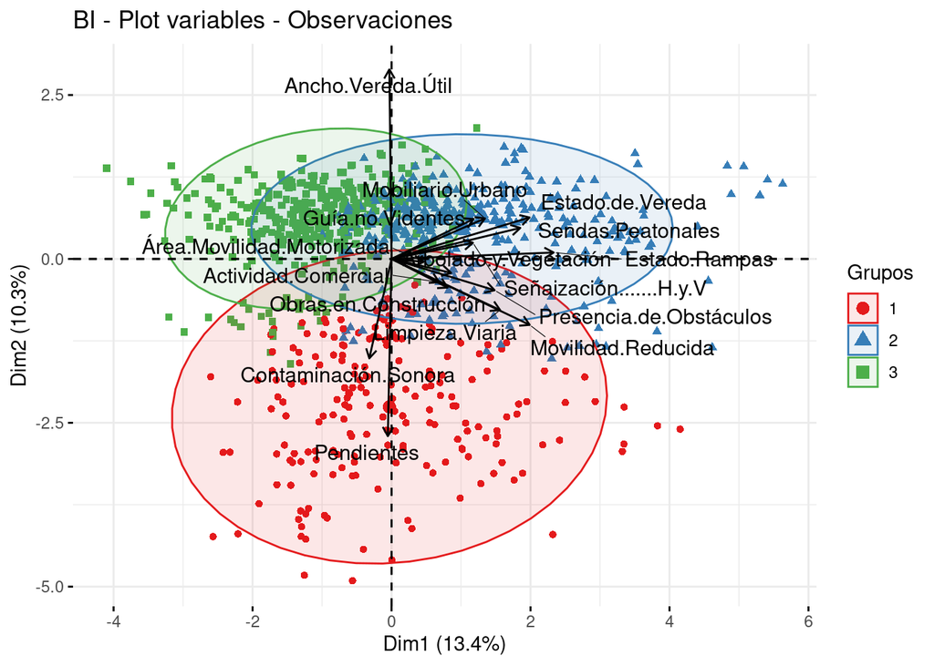

A partir de los valores propios de cada uno de estos vectores, se puede obtener el peso de cada variable. Esto no implica un orden de prelación respecto a la explicación causal de cada una de ellas en la explicación del fenómeno, sino simplementa a la manera más eficiente de extraer información útil para la generación correcta del índice buscado.

## Cálculo de índices compuestos

La metodología aplicada para el cálculo del índice es la desarrollada en (OECD, Union, and European Commission 2008), y en cálculo realizado como ejemplo se utilizará la librería de R {COINr} desarrollada por (Becker et al. 2022).

En primer lugar, se calcula un índice asignando a cada variable el mismo peso. Para ello, previamente, cada variable se escala para que varíe entre 0 y 100.

```
##    Min. 1st Qu.  Median    Mean 3rd Qu.    Max.
##   10.42   35.42   41.67   42.26   47.92   75.00
```

Posteriormente, se utilizan los valores propios del análisis de componentes principales para calcular pesos.

```
##                        iCode Level      Weight importancia
## 1      Arbolado.y.Vegetación     1 -0.16145336       4.7 %
## 2            Limpieza.Viaria     1 -0.29441688       8.6 %
## 3       Contaminación.Sonora     1  0.06024230       1.8 %
## 4    Señaización.......H.y.V     1 -0.22068934       6.5 %
## 5          Sendas.Peatonales     1 -0.34918557      10.2 %
## 6      Obras.en.Construcción     1 -0.15198358       4.5 %
## 7    Presencia.de.Obstáculos     1 -0.27949507       8.2 %
## 8  Área.Movilidad.Motorizada     1 -0.08719258       2.6 %
## 9        Actividad.Comercial     1 -0.12936487       3.8 %
## 10         Ancho.Vereda.Útil     1  0.00596313       0.2 %
## 11          Estado.de.Vereda     1 -0.37426172        11 %
## 12         Mobiliario.Urbano     1 -0.25341816       7.4 %
## 13                Pendientes     1  0.01002934       0.3 %
## 14        Movilidad.Reducida     1 -0.37460149        11 %
## 15             Estado.Rampas     1 -0.43956673      12.9 %
## 16          Guía.no.Videntes     1 -0.22239555       6.5 %
```

Luego de aplicar las ponderaciones resultantes, el nuevo Índice tiene la siguiente distribución:

```
##    Min. 1st Qu.  Median    Mean 3rd Qu.    Max.
##    6.24   36.07   45.15   45.42   53.83   92.35
```

Como se puede observar, si bien hay diferencias, la correlación entre ambos índices es positiva y estadísticamente significativa:

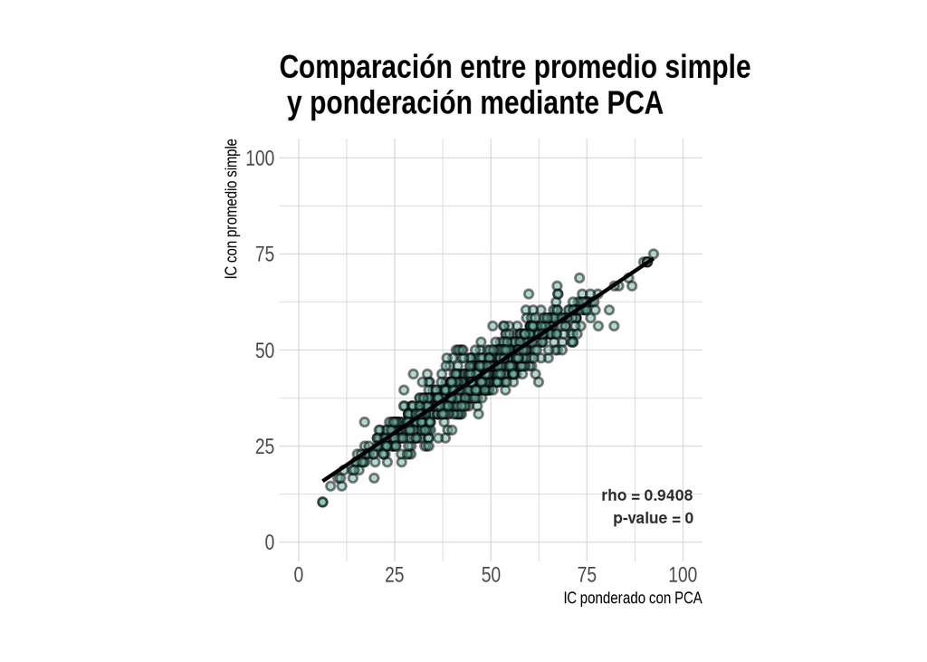

Lo anterior también puede apreciarse en un mapa interactivo, en donde la estructura del indice de caminabildiad propuesta por ambas metodologías es similar. El único cambio significativo parece ser que la ponderación a partir de PCA marca de manera más intensiva las diferencias.

[interactive chart not shown]

Referencias

Becker, William, Giulio Caperna, Maria Del Sorbo, Hedvig Norlen, Eleni Papadimitriou, and Michaela Saisana. 2022. “COINr: An r Package for Developing Composite Indicators.” *Journal of Open Source Software* 7 (78): 4567. https://doi.org/10.21105/joss.04567.

OECD, European Union, and Joint Research Centre European Commission. 2008. *Handbook on Constructing Composite Indicators: Methodology and User Guide*. https://doi.org/https://doi.org/10.1787/9789264043466-en.